# Expedition Metadata and Sites

Published

April 4, 2025

## Overview

This script processes and uploads all **site-level metadata** for the **PNG_2024** expedition to the Pristine Seas Database in BigQuery. It consolidates fieldbook records across all methods into a single, unified pipeline for QAQC, mapping, and upload.

The goals of this script are to:

1. **Import fieldbook data** for all applicable methods.
2. **Standardize site metadata** according to the Pristine Seas core site schema.
3. **Perform QAQC checks** across methods to catch early issues, such as:
   - Duplicate or malformed site IDs
   - Missing or invalid coordinates
   - Inconsistent location, habitat, or exposure values
4. **Visualize all sites** in an interactive map to confirm spatial accuracy and coverage.
5. **Summarize** sampling effort by method and locations.
6. **Upload cleaned site tables** to the appropriate method-specific datasets in BigQuery.

This centralized approach enables early validation, visualization, and reporting of spatial data across methods. While downstream datasets (e.g., BRUVS video analysis) may take months to process, site metadata can be uploaded immediately after fieldwork using fieldbooks—providing a solid foundation for future data integration and analysis.

## QAQC model

A crucial early step in building the Pristine Seas Database is to run quality checks on our fieldbooks before uploading them to BigQuery. These QA/QC checks help ensure that the data is complete, consistent, and ready for integration. The standard validation checks include:

- **No duplicated site IDs**: Each ps_site_id must be unique.
- **Invalid habitat values**: All values in the habitat column must match the controlled vocabulary: “fore reef”, “back reef”, “fringing reef”, “lagoon”, “patch reef”.
- **Invalid exposure values**: All values in the exposure column must match the controlled vocabulary: “leeward”, “windward”, “lagoon”.
- **Missing or invalid coordinates**: All sites must have non-missing latitude and longitude values, and they must fall within valid ranges (lat: −40 to 40, lon: −180 to 180).
- **Missing or invalid date**: All sites must have non-missing latitude and longitude values, and they must fall within valid ranges (lat: −40 to 40, lon: −180 to 180).
- **Visualize missing data**: Generate a missingness map to quickly inspect null values across the table.

## Surveys

This script processes site metadata from all scientific methods conducted during the expedition and harmonizes them according to the Pristine Seas **core site schema**. The following sections read the fieldbooks, apply QAQC and standardization procedures, and output cleaned site tables ready for upload.

**Core Site Fields:**  
`exp_id`, `leg`, `survey_type`, `ps_site_id`, `region`, `subregion`, `locality`, `date`, `time`, `latitude`, `longitude`, `lead`.

These form the minimal metadata required to geolocate and contextualize every sampling site.

### Underwater Visual Surveys

#### QAQC

```r
uvs_tbl_colnames <- c(core_site_fields,
                      "site_name", "habitat", "exposure", "protected",
                      "blt", "lpi", "inverts", "recruits", "ysi", "edna", "photomosaic")

uvs_habitat_vocab <- c("fore reef", "back reef", "fringing reef", "patch reef", "reef flat","channel","seagrass", "rocky reef")

uvs_exposure_vocab <- c("leeward", "windward", "lagoon")

habitat_lookup <- c("forereef" = "fore reef",
                    "patch" = "patch reef",
                    "passage" = "channel")

uvs_sites <- read_xlsx(file.path(exp_path, "data/primary/raw/_PNG-2024-uvs-metadata.xlsx")) |>
  clean_names() |>
  transmute(exp_id = exp_id,
            leg = paste("Leg", leg),
            survey_type = "uvs",
            ps_site_id = str_replace(ps_site_id, "(\\d+)$", ~ str_pad(.x, 3, pad = "0")),
            locality = str_to_title(sublocation),
            subregion = str_to_title(location),
            region = str_to_title(region),
            date = dmy(dd_mm_yyyy),
            time = as_hms(local_time),
            latitude = as.numeric(lat),
            longitude = as.numeric(lon),
            lead = team_lead,
            notes = NA_character_,
            site_name = NA_character_,
            habitat = str_to_lower(habitat),
            exposure = str_to_lower(exposure),
            protected = as.logical(NA),
            blt = as.logical(NA),
            lpi = as.logical(NA),
            inverts = as.logical(NA),
            recruits = as.logical(NA),
            ysi = as.logical(NA),
            edna = as.logical(NA),
            photomosaic = as.logical(NA)) |>
  mutate(habitat = recode(habitat, !!!habitat_lookup),
           habitat  = if_else(is.na(habitat), "unknown", habitat),
           exposure = if_else(is.na(exposure), "unknown", exposure)) |>
  select(all_of(uvs_tbl_colnames))
```

```r
validate_uvs_sites <- function(df,
                               habitat_vocab = uvs_habitat_vocab,
                               exposure_vocab = uvs_exposure_vocab,
                               lat_bounds = c(-40, 40),
                               lon_bounds = c(-180, 180),
                               date_bounds = c(as.Date("2024-01-01"), as.Date("2024-12-31"))) {

  fail_list <- list()

  # Check 1: Invalid habitat values
  fail_list$habitat <- df |>
    filter(!is.na(habitat), !habitat %in% habitat_vocab) |>
    mutate(issue = "Invalid habitat")

  # Check 2: Invalid exposure values
  fail_list$exposure <- df |>
    filter(!is.na(exposure), !exposure %in% exposure_vocab) |>
    mutate(issue = "Invalid exposure")

  # Check 3: Missing or out-of-bounds coordinates
  fail_list$coords <- df |>
    filter(is.na(latitude) | is.na(longitude) |
             latitude < lat_bounds[1] | latitude > lat_bounds[2] |
             longitude < lon_bounds[1] | longitude > lon_bounds[2]) |>
    mutate(issue = "Missing or invalid coordinates")

  # Check 4: Duplicate ps_site_id
  fail_list$duplicates <- df |>
    group_by(ps_site_id) |>
    filter(n() > 1) |>
    ungroup() |>
    mutate(issue = "Duplicate ps_site_id")

  # Check 5: Invalid or out-of-range dates
  fail_list$dates <- df |>
    filter(is.na(date) |
           date < date_bounds[1] |
           date > date_bounds[2]) |>
    mutate(issue = "Invalid or out-of-range date")

  #  Combine all failures
  fails_combined <- bind_rows(fail_list) |>
    distinct(ps_site_id, issue, .keep_all = TRUE) |>
    select(ps_site_id, region, subregion, date, habitat, exposure, latitude, longitude, issue)

  if (nrow(fails_combined) == 0) {
    cat("🎉 All UVS site QA/QC checks passed!\n")
  } else {
    message("⚠️ Issues found in UVS site data:")
    print(
      fails_combined |>
        arrange(issue, ps_site_id) |>
        gt() |>
        tab_header(title = "⚠️ UVS Sites QA/QC Issues Summary") |>
        tab_options(table.font.size = "small")
    )
  }
}

validate_uvs_sites(uvs_sites,
                   date_bounds = c(as.Date("2024-01-01"), as.Date("2024-12-31")))
```

🎉 All UVS site QA/QC checks passed!

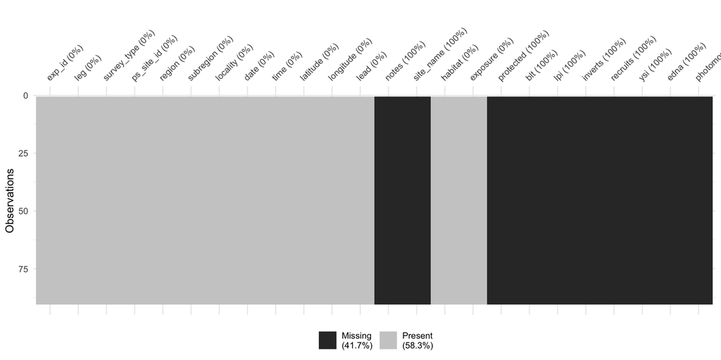

Figure 1: Missing data in UVS sites fieldbook

```r
naniar::vis_miss(uvs_sites)
```

#### Summary

We conducted underwater visual surveys in a total of **90** sites across **4** regions and **18** subregions of Papua New Guinea. We surveyed a range of habitat and exposures (Table 1)

```r
uvs_sites |>
  group_by(leg, region, habitat, exposure) |>
  summarize(n_surveys = n(),
            .groups = "drop") |>
  pivot_wider(names_from = habitat, values_from = n_surveys, values_fill = 0) |>
  gt(groupname_col = "leg") |>
  tab_options(row_group.as_column = T,
              table.width = pct(80),
              table.font.size = 12,
              table.border.top.style = "solid",
              table.border.top.width = px(1),
              table.border.top.color = "black",
              heading.align = "center",
              column_labels.font.weight = "bold")
```

Table 1: Summary of UVS survey effort by region, exposure, and habitat.

|  | region | exposure | back reef | fore reef | channel | patch reef |
| --- | --- | --- | --- | --- | --- | --- |
| Leg 1 | Lovongai | lagoon | 3 | 0 | 0 | 0 |
|  | Lovongai | leeward | 0 | 10 | 0 | 0 |
|  | Lovongai | windward | 0 | 7 | 0 | 0 |
|  | Murat | leeward | 0 | 14 | 0 | 0 |
|  | Murat | windward | 0 | 8 | 0 | 0 |
| Leg 2 | Manus | leeward | 0 | 15 | 1 | 2 |
|  | Western Islands | lagoon | 2 | 0 | 0 | 0 |
|  | Western Islands | leeward | 1 | 21 | 0 | 0 |
|  | Western Islands | windward | 0 | 6 | 0 | 0 |

**By Habitat**

```r
# Habitat map
habitat_pal <- c("fore reef"  = "#C5FFFD",
                 "back reef"  = "#DF2935",
                 "channel"    = "#D8CC34",
                 "patch reef" = "#772D8B")

uvs_sites_sf <- uvs_sites |>
  mutate(habitat = factor(habitat, levels = names(habitat_pal))) |>
  sf::st_as_sf(coords = c("longitude", "latitude"), crs = 4326) |>
  distinct(ps_site_id, habitat, exposure, geometry)

mapview::mapview(
  uvs_sites_sf,
  zcol = "habitat",
  legend = TRUE,
  col.regions = habitat_pal,
  map.types = "Esri.WorldImagery",
  layer.name = "Habitat",
  popup = leafpop::popupTable(uvs_sites_sf, zcol = c("ps_site_id", "habitat", "exposure"))
)
```

[interactive chart not shown]

**By Exposure**

```r
# Exposure map
exposure_pal <- c("leeward"  = "#1f78b4",
                  "windward" = "#33a02c",
                  "lagoon"   = "#ff7f00")

uvs_sites_sf <- uvs_sites_sf |>
  mutate(exposure = factor(exposure, levels = names(exposure_pal)))

mapview::mapview(
  uvs_sites_sf,
  zcol = "exposure",
  legend = TRUE,
  col.regions = exposure_pal,
  map.types = "Esri.WorldImagery",
  layer.name = "Exposure",
  popup = leafpop::popupTable(uvs_sites_sf, zcol = c("ps_site_id", "habitat", "exposure"))
)
```

[interactive chart not shown]

#### Stations

##### Fish - BLT

###### QAQC

```r
diver_files <- list(AMF = "PNG_2024_fish_fieldbook_AMF.xlsx",
                    ALG = "PNG_2024_fish_fieldbook_ALG_FINAL.xlsx",
                    VAS = "PNG_2024_fish_fieldbook_VAS.xlsx",
                    JEC = "PNG_2024_fish_fieldbook_JEC_FINAL.xlsx",
                    AJM = "PNG_2024_fish_fieldbook_AJKM_Final_clean.xlsx")

fish_stations <- map_dfr(diver_files,
                         ~ get_fish_stations(file = file.path("data/primary/raw/fish", .x),
                                             exp_id = "PNG_2024")) |>
  arrange(ps_station_id) |>
  left_join(uvs_sites, by = c("exp_id", "ps_site_id", "survey_type") ) |>
  select(exp_id, survey_type, ps_site_id, ps_station_id, method, diver, depth_m, depth_strata,
         n_transects, area_m2, date, time, region, subregion, locality, habitat, exposure, notes) |>
  mutate(exposure = if_else(is.na(exposure), "unknown", exposure),
         habitat = if_else(is.na(habitat), "unknown", habitat))
```

```
⚠️ 3 station(s) in PNG_2024_fish_fieldbook_ALG_FINAL.xlsx have inconsistent depth labels.
```

```
⚠️ 10 station(s) in PNG_2024_fish_fieldbook_JEC_FINAL.xlsx have inconsistent depth labels.
```

```
⚠️ 2 station(s) less or more transects than expected in: PNG_2024_fish_fieldbook_JEC_FINAL.xlsx
```

###### Summary

```r
fish_stations |>
  left_join(uvs_sites |>
              select(ps_site_id, leg), by = "ps_site_id") |>
  group_by(leg, region,  habitat, depth_strata) |>
  summarise(n = n_distinct(ps_station_id), .groups = "drop") |>
  pivot_wider(names_from = habitat, values_from = n, values_fill = 0) |>
  gt(groupname_col = "leg") |>
  tab_options(table.font.size = 12,
              table.width = pct(80),
              row_group.as_column = T) |>
  tab_source_note(source_note = "Depth stratum: supershallow (< 5 m), shallow (5 - 15 m), and deep (>= 15 m).")
```

Table 2: Summary of fish surveys by habitat and depth strata

|  | region | depth_strata | back reef | fore reef | channel | patch reef |
| --- | --- | --- | --- | --- | --- | --- |
| Leg 1 | Lovongai | shallow | 3 | 16 | 0 | 0 |
|  | Lovongai | deep | 0 | 9 | 0 | 0 |
|  | Lovongai | supershallow | 0 | 1 | 0 | 0 |
|  | Murat | deep | 0 | 22 | 0 | 0 |
|  | Murat | shallow | 0 | 22 | 0 | 0 |
| Leg 2 | Manus | shallow | 0 | 15 | 1 | 1 |
|  | Manus | supershallow | 0 | 2 | 1 | 1 |
|  | Manus | deep | 0 | 13 | 0 | 2 |
|  | Western Islands | deep | 1 | 26 | 0 | 0 |
|  | Western Islands | shallow | 2 | 27 | 0 | 0 |
|  | Western Islands | supershallow | 2 | 1 | 0 | 0 |

Depth stratum: supershallow (< 5 m), shallow (5 - 15 m), and deep (>= 15 m).

##### Benthos - LPI

###### QAQC

```r
lpi_stations_leg2 <- get_lpi_stations(file  = "data/primary/raw/benthos/PNG_2024_lpi_fieldsheet_Emma.xlsx",
                                      sheet = "transects",
                                      range = "F3:ND5",
                                      exp_id = "PNG_2024",
                                      diver  = "EC")
```

```
⚠️ 35 station(s) have fewer than 5 sections in:PNG_2024_lpi_fieldsheet_Emma.xlsx
```

```r
lpi_stations_leg1 <- get_lpi_stations(file  = "data/primary/raw/benthos/PNG_2024_lpi_fieldsheet_Quim.xlsx",
                                      sheet = "transects",
                                      range = "I3:PL5",
                                      exp_id = "PNG_2024",
                                      diver  = "QG")
```

```
⚠️ 3 station(s) have fewer than 5 sections in:PNG_2024_lpi_fieldsheet_Quim.xlsx
```

```r
lpi_stations_kat <- get_lpi_stations(file  = "data/primary/raw/benthos/PNG_2024_lpi_fieldsheet_Kat.xlsx",
                                     sheet = "transects",
                                     range = "H2:Q4",
                                     exp_id = "PNG_2024",
                                     diver  = "KM")

lpi_stations <- bind_rows(lpi_stations_leg1,
                          lpi_stations_leg2,
                          lpi_stations_kat) |>
  select(exp_id, survey_type, method, ps_site_id, ps_station_id, depth_strata, depth_m, n_sections, length_m, diver) |>
  left_join(uvs_sites,
            by = c("exp_id", "ps_site_id", "survey_type") ) |>
  select(exp_id, survey_type, ps_site_id, method, ps_station_id, diver, depth_m, depth_strata,
         n_sections, length_m, date, time, region, subregion, locality, habitat, exposure, notes)
```

###### Summary

We conducted a total of **157** LPI stations (site x depth strata) across **18** locations. We conducted benthic LPI surveys at **99** % of the uvs sites and sampled the following habitats and depth strata:

```r
lpi_stations |>
  left_join(uvs_sites |>
              select(ps_site_id, leg), by = "ps_site_id") |>
  group_by(leg, region, habitat, depth_strata) |>
  summarise(n = n_distinct(ps_station_id), .groups = "drop") |>
  pivot_wider(names_from = habitat, values_from = n, values_fill = 0) |>
  gt(groupname_col = "leg") |>
  tab_options(table.font.size = 12,
              table.width = pct(80),
              row_group.as_column = T) |>
  tab_source_note(source_note = "Depth stratum: supershallow (< 5 m), shallow (5 - 15 m), and deep (>= 15 m).")
```

Table 3: Summary of benthic surveys by habitat and depth strata

|  | region | depth_strata | back reef | fore reef | channel | patch reef |
| --- | --- | --- | --- | --- | --- | --- |
| Leg 1 | Lovongai | shallow | 3 | 16 | 0 | 0 |
|  | Lovongai | deep | 0 | 8 | 0 | 0 |
|  | Lovongai | supershallow | 0 | 1 | 0 | 0 |
|  | Murat | deep | 0 | 22 | 0 | 0 |
|  | Murat | shallow | 0 | 22 | 0 | 0 |
| Leg 2 | Manus | shallow | 0 | 15 | 1 | 1 |
|  | Manus | deep | 0 | 11 | 0 | 1 |
|  | Manus | supershallow | 0 | 0 | 0 | 1 |
|  | Western Islands | deep | 1 | 24 | 0 | 0 |
|  | Western Islands | shallow | 2 | 26 | 0 | 0 |
|  | Western Islands | supershallow | 1 | 1 | 0 | 0 |

Depth stratum: supershallow (< 5 m), shallow (5 - 15 m), and deep (>= 15 m).

###### What stations have fish surveys but not LPI?

```r
# 1. Get station-level presence for each method
fish_ids <- fish_stations |> distinct(ps_station_id) |> mutate(has_fish = TRUE)
lpi_ids  <- lpi_stations  |> distinct(ps_station_id) |> mutate(has_lpi = TRUE)

# 2. Full join to capture all stations
station_compare <- full_join(fish_ids, lpi_ids, by = "ps_station_id") |>
  mutate(across(c(has_fish, has_lpi), ~replace_na(.x, FALSE))) |>
  filter(!(has_fish & has_lpi))  # Keep only those missing one

# 3. Optional: add context (e.g., from fish_stations)
station_details <- fish_stations |>
  bind_rows(lpi_stations) |>
  distinct(ps_station_id, ps_site_id, depth_strata, exp_id)  # light joinable metadata

mismatch_table <- station_compare |>
  left_join(station_details, by = "ps_station_id") |>
  select(exp_id, ps_site_id, ps_station_id, has_fish, has_lpi, depth_strata) |>
  arrange(ps_station_id)

# 4. Display
if (nrow(mismatch_table) == 0) {
  cat("✅ All stations have both Fish and LPI surveys.\n")
} else {
  message("⚠️ ", nrow(mismatch_table), " station(s) are missing either fish or LPI:")
  print(
    mismatch_table |>
      select(ps_station_id, has_fish, has_lpi, depth_strata) |>
      gt() |>
      tab_header(title = md("⚠️ **Stations Missing One Method (Fish or LPI)**")) |>
      tab_options(table.font.size = 12)
  )
}
```

```
⚠️ 11 station(s) are missing either fish or LPI:
```

⚠️ **Stations Missing One Method (Fish or LPI)**

| ps_station_id | has_fish | has_lpi | depth_strata |
| --- | --- | --- | --- |
| PNG_2024_uvs_031_20m | TRUE | FALSE | deep |
| PNG_2024_uvs_051_05m | TRUE | FALSE | supershallow |
| PNG_2024_uvs_052_05m | TRUE | FALSE | supershallow |
| PNG_2024_uvs_053_20m | TRUE | FALSE | deep |
| PNG_2024_uvs_058_20m | TRUE | FALSE | deep |
| PNG_2024_uvs_059_05m | TRUE | FALSE | supershallow |
| PNG_2024_uvs_060_20m | TRUE | FALSE | deep |
| PNG_2024_uvs_067_10m | TRUE | FALSE | shallow |
| PNG_2024_uvs_067_20m | TRUE | FALSE | deep |
| PNG_2024_uvs_074_05m | TRUE | FALSE | supershallow |
| PNG_2024_uvs_078_20m | TRUE | FALSE | deep |

##### Coral recruits

###### QAQC

```r
recruits_stations <- readxl::read_xlsx(file.path(exp_path, "data/primary/raw/benthos/PNG_2024_recruits_fieldsheet_MT.xlsx"),
                                       sheet = "Coral Recruits") |>
  clean_names() |>
  rename(depth_m = depth, n_quadrats = quadrats, diver = observer) |>
  mutate(exp_id         = exp_id,
         survey_type    = "uvs",
         depth_m        = round(as.numeric(depth_m), 0),
         site_num       = str_extract(site, "\\d+") |> str_pad(3, pad = "0"),
         ps_site_id     = paste(exp_id, "uvs", site_num, sep = "_"),
         depth_strata   = assign_depth_stratum(depth_m),
         station_suffix = recode(depth_strata, !!!stratum_to_suffix),
         ps_station_id  = paste0(ps_site_id, "_", station_suffix),
         method         = "recruits") |>
  group_by(exp_id, survey_type, ps_site_id, ps_station_id, diver, depth_m, depth_strata, method) |>
  summarise(n_quadrats = mean(n_quadrats, na.rm = TRUE),
            .groups = "drop") |>
  select(exp_id, survey_type , ps_site_id, ps_station_id, method, diver, depth_m, depth_strata, n_quadrats) |>
  arrange(ps_station_id) |>
  left_join(uvs_sites,
            by = c("exp_id", "survey_type","ps_site_id") ) |>
  select(exp_id, survey_type, ps_site_id, method, ps_station_id, diver, depth_m, depth_strata, n_quadrats, date, time,
         region, subregion, locality, habitat, exposure, notes)
```

###### Summary

We conducted a total of **61** coral recruits stations (site x depth strata) across **11** subregions We conducted coral recruits surveys at **42** % of the uvs sites.

##### Invertebrates

###### QAQC

```r
inverts_stations <- readxl::read_xlsx(file.path(exp_path,
                                                "data/primary/raw/benthos/PNG_2024_inverts_fieldsheet_MT.xlsx"),
                                      sheet = "Invert") |>
  clean_names() |>
  filter(transect != "Off") |>
  rename(depth_m       = depth,
         diver         = observer) |>
  mutate(exp_id        = exp_id,
         survey_type   = "uvs",
         method        = "inverts",
         depth_m       = round(as.numeric(depth_m), 0),
         site_num      = str_extract(site, "\\d+") |> str_pad(3, pad = "0"),
         ps_site_id    = paste(exp_id, "uvs", site_num, sep = "_"),
         depth_strata  = assign_depth_stratum(depth_m),
         station_suffix = recode(depth_strata, !!!stratum_to_suffix),
         ps_station_id  = paste0(ps_site_id, "_", station_suffix) ) |>
  distinct(exp_id, survey_type, ps_site_id, ps_station_id, method, diver, depth_m, depth_strata) |>
  arrange(ps_station_id)

inverts_stations <- inverts_stations |>
  left_join(uvs_sites, by = c("exp_id", "survey_type","ps_site_id")) |>
  select(exp_id, survey_type, ps_site_id, method, ps_station_id, diver, depth_m, depth_strata, date, time,
          region, subregion, locality,  habitat, exposure, notes)
```

###### Summary

We conducted a total of **68** invertebrate stations (site x depth strata) across **11** locations. We conducted invertebrate surveys at **44** % of the uvs sites.

##### eDNA

###### QAQC

```r
edna_samples <- read_xlsx(file.path(exp_path, "data/primary/raw/edna/PNG_2024_edna_fieldbook.xlsx"),
                          sheet = "metadata") |>
  clean_names() |>
  mutate(exp_id         = exp_id,
         method         = "edna",
         survey_type    = "edna",
         leg            = paste("Leg", leg),
         depth_m        = round(as.numeric(depth_m)),
         replicate      = str_extract(ps_sample_id, "\\d+$"),
         site_num       = str_extract(ps_station_id, "\\d+$") |> str_pad(3, pad = "0"),
         ps_site_id     = paste(exp_id, "edna", site_num, sep = "_"),
         depth_strata   = assign_depth_stratum(depth_m),
         station_suffix = recode(assign_depth_stratum(depth_m), !!!stratum_to_suffix),
         ps_station_id  = paste0(ps_site_id, "_", station_suffix),
         ps_sample_id   = paste0(ps_station_id, "_r", replicate),
         paired_site_id = str_replace(paired_station_id, "\\d+$", \(x) str_pad(x, 3, pad = "0")),
         date           = ymd(date),
         time           = as_hms(collection_time),
         filter_date    = ymd(filter_date),
         filter_time    = as_hms(filter_time))

# === Add region & finalize fields ===
region_lookup <- uvs_sites |> distinct(location = subregion, region)

edna_samples <- edna_samples |>
  left_join(region_lookup, by = "location") |>
  rename(subregion = location,
         locality = sublocation,
         latitude = lat,
         longitude = lon,
         lead = team_lead) |>
  mutate(region = case_when(subregion %in% c("Metemin", "Metevoi") ~ "Lovongai",
                            TRUE ~ region)) |>
  select(all_of(core_site_fields),
         method, ps_station_id, paired_site_id, ps_sample_id, replicate, depth_strata, depth_m, water_liters,
         preservative, filter_date, filter_time, filter_type, filter_size_um, target, habitat, site_photos) |>
  arrange(ps_station_id)

# === Sites summary ===
edna_sites <- edna_samples |>
  group_by(exp_id, leg, survey_type, ps_site_id, region, subregion, locality,
           date, time, latitude, longitude, lead, paired_site_id, habitat, site_photos) |>
  summarize(n_stations = n_distinct(ps_station_id),
            n_samples  = n_distinct(ps_sample_id),
            notes      = first(na.omit(notes)), .groups = "drop")

# === Stations summary ===
edna_stations <- edna_samples |>
  group_by(exp_id, method, ps_station_id, ps_site_id, paired_site_id, depth_strata,
           depth_m, filter_type, filter_size_um, filter_date, filter_time, target) |>
  summarize(n_replicates = n_distinct(ps_sample_id),
            water_liters = sum(water_liters, na.rm = TRUE),
            notes        = first(na.omit(notes)), .groups = "drop") |>
  relocate(ps_site_id, .after = ps_station_id)

# === Flag stations with missing replicates ===
flagged <- edna_stations |> filter(n_replicates != 3)

if (nrow(flagged) > 0) {
  cli::cli_warn("⚠️ {nrow(flagged)} station(s) have fewer or more than 3 eDNA replicates.")
}
```

##### YSI

###### QAQC

```r
ysi_sites_leg_1 <- read_xlsx(file.path(exp_path, "data/primary/raw/ysi/PNG_2024_ysi_fieldbook_leg_1.xlsx")) |>
  mutate(ps_site_id = str_replace(ps_station_id, "(\\d+)$", \(x) str_pad(x, 3, pad = "0"))) |>
  distinct(ps_site_id) |>
  pull()

ysi_raw_leg_2 <- list.files(path = file.path(exp_path, "data/primary/raw/ysi"),
                              pattern = "KorDSS Measurement File Export.*\\.csv$",
                              full.names = TRUE) |>
  read_csv(skip = 5, show_col_types = FALSE) |>
  clean_names() |>
  mutate(date = mdy(date),
         datetime = as_datetime(date) + time)

ysi_casts_leg_2 <- ysi_raw_leg_2 |>
  arrange(datetime) |>
  mutate(time_diff_secs = as.numeric(difftime(datetime, lag(datetime), units = "secs")),
         cast_id = cumsum(if_else(is.na(time_diff_secs) | time_diff_secs > 300, 1, 0))) |>
  group_by(cast_id) |>
  summarise(cast_duration_sec = as.numeric(difftime(max(datetime), min(datetime), units = "secs")),
            datetime = min(datetime),
            n_pings = n(),
            max_depth_m = max(depth_m, na.rm = TRUE),
            .groups = "drop") |>
  filter(cast_duration_sec >= 30,  # at least 30 seconds long
         n_pings >= 5 )             # at least 5 pings

library(fuzzyjoin)

ysi_casts_matched <- fuzzy_left_join(ysi_casts_leg_2,
                                     uvs_sites |>
                                       mutate(datetime = as_datetime(date) + time) |>
                                       select(ps_site_id, datetime),
                                     by = c("datetime" = "datetime"),
                                     match_fun = list(\(x, y) abs(difftime(x, y, units = "mins")) < 40))


# After manually reviewed the casts, we will make the manual adjustement

ysi_casts_matched$ps_site_id[ysi_casts_matched$cast_id == 22] <- "PNG_2024_uvs_062"
ysi_casts_matched$ps_site_id[ysi_casts_matched$cast_id == 29] <- "PNG_2024_uvs_061"
ysi_casts_matched$ps_site_id[ysi_casts_matched$cast_id == 48] <- "PNG_2024_uvs_088"

ysi_casts_matched <- ysi_casts_matched |>
  filter(!is.na(ps_site_id)) |>
  rename(datetime = datetime.x) |>
  select(-datetime.y) |>
  mutate(method = "ysi",
         ps_station_id = ps_site_id)

ysi_sites <- tibble(ps_site_id = unique(c(ysi_casts_matched$ps_site_id, ysi_sites_leg_1))) |>
  left_join(uvs_sites, by = "ps_site_id") |>
  filter(ps_site_id != "PNG_2024_uvs_SPAG") |>
  rename(paired_site_id = ps_site_id) |>
  arrange(paired_site_id) |>
  mutate(survey_type = "ysi",
         cast_number = str_pad(row_number(), 3, pad = "0"),
         ps_site_id = paste(exp_id, survey_type, cast_number, sep = "_")) |>
  arrange(ps_site_id) |>
  select(c(core_site_fields, "paired_site_id", "habitat", "exposure"))
```

#### Site coverage

The following table summarizes the coverage of each method across the UVS sites:

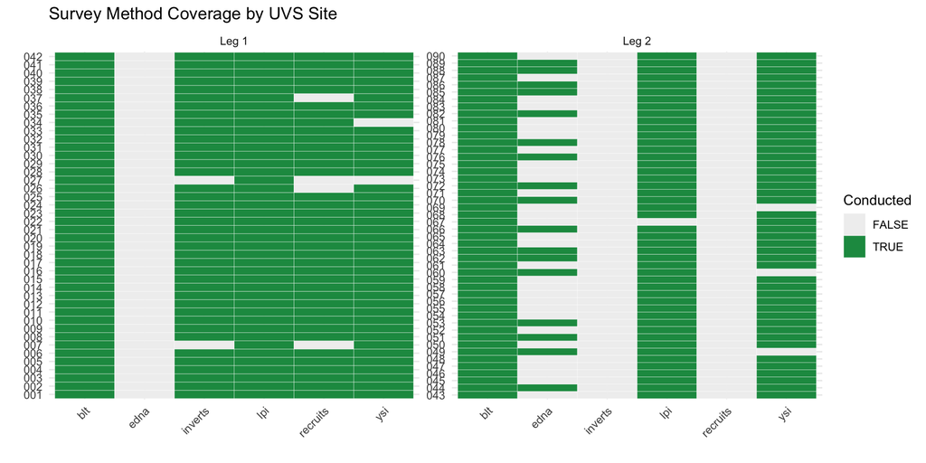

Figure 2: Coverage of UVS survey methods (fish, LPI, recruits, inverts, eDNA) at each site.

```r
uvs_sites <- uvs_sites |>
  mutate(blt         = ps_site_id %in% fish_stations$ps_site_id,
         lpi         = ps_site_id %in% lpi_stations$ps_site_id,
         inverts     = ps_site_id %in% inverts_stations$ps_site_id,
         recruits    = ps_site_id %in% recruits_stations$ps_site_id,
         edna        = ps_site_id %in% edna_sites$paired_site_id,
         ysi         = ps_site_id %in% ysi_sites$paired_site_id,
         photomosaic = FALSE)

uvs_sites |>
  select(leg, ps_site_id, blt, lpi, inverts, recruits, ysi, edna) |>
  pivot_longer(-c(leg, ps_site_id),
               names_to = "method",
               values_to = "conducted") |>
  mutate(site_number = str_extract(ps_site_id, "\\d+$")) |>
  ggplot(aes(x = method, y = site_number, fill = conducted)) +
  geom_tile(color = "white",
            linewidth = 0.1) +
  scale_fill_manual(values = c("TRUE" = "#1a9850", "FALSE" = "#f0f0f0")) +
  labs(title = "Survey Method Coverage by UVS Site",
       x = "", y = "",
       fill = "Conducted") +
  theme_minimal() +
  theme(axis.text.x = element_text(angle = 45, hjust = 1))+
  facet_wrap(~leg, scales = "free_y")
```

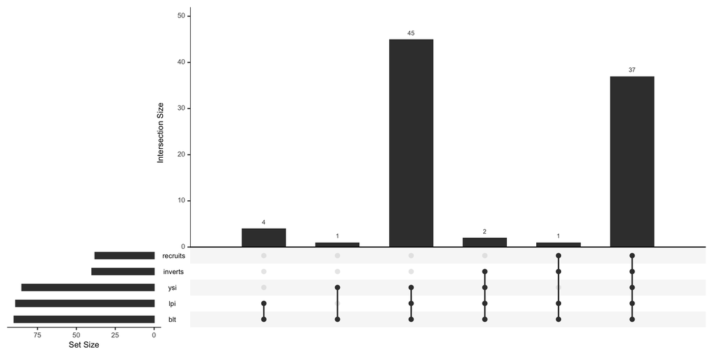

Figure 3: Patterns of data overlap across UVS methods (BLT, LPI, inverts, recruits, YSI).

```r
library(UpSetR)

method_sets <- uvs_sites |>
  select(ps_site_id, blt, lpi, inverts, recruits, ysi, edna) |>
  pivot_longer(-ps_site_id, names_to = "method", values_to = "present") |>
  filter(present == TRUE) |>
  group_by(method) |>
  summarise(sites = list(ps_site_id), .groups = "drop") |>
  deframe()

# Generate UpSet plot
upset(fromList(method_sets))
```

```r
# Sites object with only UVS sites
sites <- list(uvs = uvs_sites,
              edna = edna_sites,
              ysi = ysi_sites)

# Stations object with fish and LPI stations
stations <- list(fish = fish_stations,
                 lpi  = lpi_stations,
                 recuits = recruits_stations,
                 inverts = inverts_stations)

write_rds(sites,
          file.path(exp_path, "data/primary/processed/sites.rds"))

write_rds(stations,
          file.path(exp_path, "data/primary/processed/stations.rds"))
```

### Seabed BRUVS

#### QAQC

```r
region_lookup <- uvs_sites |> distinct(location = subregion, region)

sbruvs_raw <- read_xlsx(file.path(exp_path, "data/primary/raw/bruvs/PNG_2024_bruvs_fieldbook.xlsx"),
                          sheet = "metadata") |>
  clean_names() |>
  rename(lead = team_lead) |>
  mutate(exp_id = "PNG_2024",
         survey_type = "sbruvs",
         method = "seabed BRUVS",
         ps_site_id =   str_replace(ps_station_id, "(\\d+)$", \(x) str_pad(x, 3, pad = "0")),
         ps_station_id = paste(ps_site_id, paste0(round(depth_m), "m"), sep = "_"),
         date = ymd(date),
         time = as_hms(time_in),
         depth_m = as.numeric(depth_m),
         location = str_to_title(location),
         sublocation = str_to_title(sublocation),
         habitat = NA_character_,
         exposure = NA_character_)

sbruvs_stations <- sbruvs_raw |>
  left_join(region_lookup, by = "location") |>
  rename(subregion = location,
         locality = sublocation) |>
  mutate(region = case_when(subregion == "Emanaus" ~ "Murat",
                            subregion %in% c("Tsoilik", "Metenmin", "Anelava", "Metevoi") ~ "Lovongai",
                            TRUE ~ region)) |>
  select(all_of(core_site_fields),
         ps_station_id, depth_m, rig, cam_l, cam_r, habitat, exposure, bottom_type)

sbruvs_sites <- sbruvs_stations |>
  select(all_of(core_site_fields), habitat, exposure) |>
  mutate(habitat = if_else(is.na(habitat), "unknown", habitat),
         exposure = if_else(is.na(exposure), "unknown", exposure)) |>
  distinct()

sbruvs_stations <- sbruvs_stations |>
  select(exp_id, survey_type, ps_station_id, ps_site_id, depth_m, rig, cam_l, cam_r, bottom_type, notes)
```

#### Summary

We deployed a total of **145** seabed BRUVS distributed across **20** locations and **4** study regions.

```r
# Regions palette

regions_pal <- c("Lovongai"  = "#FABC2A",
                "Manus"  = "#44FFD1",
                "Murat"    = "#275DAD",
                "Western Islands" = "#FF69EB")

sbruvs_sites_sf <- sbruvs_sites |>
  mutate(region = factor(region, levels = names(regions_pal))) |>
  sf::st_as_sf(coords = c("longitude", "latitude"), crs = 4326) |>
  distinct(ps_site_id, region, exposure, geometry)

mapview::mapview(sbruvs_sites_sf,
                 zcol = "region",
                 legend = TRUE,
                 col.regions = regions_pal,
                 map.types = "Esri.WorldImagery",
                 layer.name = "Region",
                 popup = leafpop::popupTable(sbruvs_sites_sf, zcol = c("ps_site_id", "region", "exposure")))
```

[interactive chart not shown]

### Pelagic BRUVS

#### QAQC

```r
qaqc_warn_pbruvs <- function(df,
                             max_drift_m = 5000,
                             max_drift_hours = 3,
                             expected_n_rigs = 5) {
  require(dplyr)

  # Drift distance
  n_drift_exceeds <- df |> filter(drift_m > max_drift_m) |> nrow()
  if (n_drift_exceeds > 0) message(glue::glue("⚠️  {n_drift_exceeds} station(s) with drift > {max_drift_m} m"))

  # Drift time issues
  n_drift_zero <- df |> filter(drift_hrs <= 0) |> nrow()
  if (n_drift_zero > 0) message("⚠️  ", n_drift_zero, " station(s) with nonpositive drift time")

  n_drift_exceeds_time <- df |> filter(drift_hrs > max_drift_hours) |> nrow()
  if (n_drift_exceeds_time > 0) message(glue::glue("⚠️  {n_drift_exceeds_time} station(s) with drift time > {max_drift_hours} hours"))

  # Missing coordinates
  n_missing_coords <- df |> filter(is.na(lat_in) | is.na(long_in) | is.na(lat_out) | is.na(long_out)) |> nrow()
  if (n_missing_coords > 0) message("⚠️  ", n_missing_coords, " station(s) with missing coordinates")

  # Too few rigs per site
  n_few_rigs <- df |> count(ps_site_id) |> filter(n < expected_n_rigs) |> nrow()
  if (n_few_rigs > 0) message("⚠️  ", n_few_rigs, " site(s) with fewer than ", expected_n_rigs, " rigs")

  # Duplicate rigs
  n_dup_rigs <- df |> count(ps_site_id, rig) |> filter(n > 1) |> nrow()
  if (n_dup_rigs > 0) message("⚠️  ", n_dup_rigs, " duplicated rig(s) within site(s)")

  # If no issues found
  if (n_drift_exceeds + n_drift_zero + n_drift_exceeds_time + n_missing_coords + n_few_rigs + n_dup_rigs == 0) {
    message("✅ No QAQC issues found in pBRUV stations.")
  }
}
```

```r
pbruvs_raw <- read_xlsx(file.path(exp_path, "data/primary/raw/pelagics/PNG_2024_pelagics_fieldbook_2024_10_01.xlsx"),
                        sheet = "Metadata") |>
  clean_names()

pbruvs_stations <- pbruvs_raw |>
  mutate(exp_id = "PNG_2024",
         survey_type = "pbruvs",
         method = "pelagic BRUVS",
         ps_site_id = str_replace(string, "(\\d+)$", \(x) str_pad(x, 3, pad = "0")),
         ps_site_id = str_replace(ps_site_id, "PNGP24", "PNG_2024_pbruvs"),
         ps_station_id = paste(ps_site_id, paste0("r",round(rig) ), sep = "_"),
         sublocation = str_to_title(sublocation),
         location = str_to_title(location),
         date = ymd(date),
         time_in = as_hms(time_in),
         time_out = as_hms(time_out),
         drift_hrs = as.numeric(round(difftime(time_out, time_in, units = "hours"),2)),
         drift_m =  round(as.numeric(geosphere::distHaversine(matrix(c(long_in, lat_in), ncol = 2),
                                                              matrix(c(long_out, lat_out), ncol = 2))), 2))|>
  rename(uwa_opcode = opcode, uwa_string = string, notes = field_comments) |>
  select(exp_id, leg, survey_type, method, ps_site_id, ps_station_id, location, sublocation, date,
         rig, left_cam, right_cam, time_in, time_out, contains("lat_"), contains("long_"), drift_hrs, drift_m,
         bait, uwa_opcode, uwa_string, species_notes, notes, team_lead) |>
  left_join(region_lookup, by = "location") |>
  rename(subregion = location,
         locality = sublocation,
         lead = team_lead) |>
  mutate(region = case_when(subregion %in% c("Emanaus", "Eloaua") ~ "Murat",
                            subregion %in% c("Tsoilik", "Metenmin", "Anelava", "Metovai") ~ "Lovongai",
                            TRUE ~ region))

# Run QAQC

qaqc_warn_pbruvs(pbruvs_stations)
```

```
⚠️  15 station(s) with drift > 5000 m
```

```r
# Sites table

pbruvs_sites <- pbruvs_stations |>
  group_by(exp_id, leg, survey_type, ps_site_id, uwa_string, region, subregion, locality, date, lead) |>
  summarise(time = first(na.omit(time_in)),
            latitude = mean(lat_in, na.rm = T),
            longitude = mean(long_in, na.rm = T),
            n_rigs = n_distinct(ps_station_id),
            drift_m = round(mean(drift_m),2),
            drift_hrs = round(mean(drift_hrs),2),
            notes = first(na.omit(notes)),
            .groups = "drop") |>
  select(all_of(core_site_fields), n_rigs, drift_m, drift_hrs)
```

#### Summary

We deployed a total of **51** pelagic BRUVS distributed across **17** locations and **4** study regions.

```r
pbruvs_sites_sf <- pbruvs_sites |>
  sf::st_as_sf(coords = c("longitude", "latitude"), crs = 4326) |>
  distinct(ps_site_id, region, drift_hrs, drift_m, n_rigs, geometry)

mapview::mapview(pbruvs_sites_sf,
                 zcol = "region",
                 legend = TRUE,
                 col.regions = regions_pal,
                 map.types = "Esri.WorldImagery",
                 layer.name = "Region",
                 popup = leafpop::popupTable(pbruvs_sites_sf, zcol = c("ps_site_id", "region", "n_rigs", "drift_hrs","drift_m")))
```

[interactive chart not shown]

### Birds

#### QAQC

```r
birds_raw <- read_xlsx(file.path(exp_path, "data/primary/raw/birds/PNG_2024_birds_fieldbook_2024_10_02.xlsx"),
                        sheet = "transect",
                       range = cell_cols("A:R")) |>
  clean_names()

birds_stations <- birds_raw |>
  select(-time) |>
  rename(leg = exp_leg,
         uwa_string = paired_string_id,
         lead = team_member) |>
  mutate(exp_id = "PNG_2024",
         survey_type = "birds",
         method = "transects",
         ps_station_id = ps_site_id,
         date = ymd(date),
         across(c(start_time, stop_time), as_hms),
         across(c(start_lat, start_lon, stop_lat, stop_lon, distance), as.numeric),
         duration_hrs = as.numeric(round(difftime(stop_time, start_time, units = "hours"), 2)),
         linear_dist_m = round(as.numeric(geosphere::distHaversine(matrix(c(start_lon, start_lat), ncol = 2),
                                                                 matrix(c(stop_lon, stop_lat), ncol = 2))), 2),
         distance_m = coalesce(distance*1000, linear_dist_m)) |>
  select(exp_id, method, ps_site_id, ps_station_id, location , sublocation , date, contains("time"), contains("start_l"), contains("stop_l"),
         vessel, duration_hrs, distance_m, uwa_string, in_or_out, notes, everything())

birds_stations <- birds_stations |>
  left_join(region_lookup, by = "location") |>
  rename(subregion = location,
         locality = sublocation) |>
  mutate(region = case_when(subregion %in% c("Emanaus", "Eloaua") ~ "Murat",
                            subregion %in% c("Tsoi","Tsoilik", "Metenmin", "Anelava", "Metovai") ~ "Lovongai",
                            TRUE ~ region))

birds_sites <- birds_stations |>
  mutate(time = start_time,
         latitude = start_lat,
         longitude = start_lon,
         habitat = case_when(vessel %in% c("Argo", "Rhib") ~ "coastal",
                             vessel %in% c("Land", "Land/bike") ~ "inland",
                             TRUE ~ NA_character_)) |>
  select(all_of(core_site_fields), habitat)
```

#### Summary

```r
birds_sites_sf <- birds_sites |>
  filter(!is.na(longitude)) |>
  sf::st_as_sf(coords = c("longitude", "latitude"), crs = 4326) |>
  distinct(ps_site_id, region, habitat, geometry)

mapview::mapview(birds_sites_sf,
                 zcol = "habitat",
                 legend = TRUE,
                 col.regions = c("coastal" = "#B9E6FF", "inland" = "#F87575"),
                 map.types = "Esri.WorldImagery",
                 layer.name = "Habitat",
                 popup = leafpop::popupTable(pbruvs_sites_sf, zcol = c("ps_site_id", "region")))
```

[interactive chart not shown]

### Submersible

#### QAQC

```r
sub_raw <- read_xlsx(file.path(exp_path, "data/primary/raw/sub/PNG_2024_sub_metadata.xlsx"),
                        sheet = "metadata") |>
  clean_names()

sub_sites <- sub_raw |>
  transmute(### Core fields ----
            exp_id = "PNG_2024",
            survey_type = "sub",
            leg = "Leg 2",
            ps_site_id = str_replace(str_replace(ps_station_id, "(\\d+)$", \(x) str_pad(x, 3, pad = "0")), "PNG", "PNG_2024"),
            location = str_to_title(location),
            sublocation = str_to_title(sublocation),
            date = dmy(date_dd_mm_yyyy),
            time = as_hms(start_time_local),
            latitude = start_lat_surface,
            longitude = start_lon_surface,
            lead = observer_1,  # assuming primary observer =  lead
            notes = notes,
            ### Method-specific fields (sub) ----
            sub_name = "Argonauta",
            dive_number = dive_num,
            depth_max_m = as.numeric(depth_max_m),
            duration = as_hms(dive_duration),
            temp_max_depth_c = as.numeric(temp_max_depth_c),
            observer_1 = observer_1,
            observer2 = observer_2,
            pilot = pilot,
            dive_type = dive_type,
            collection = FALSE,
            transect = if_else(transect == "Y", TRUE, FALSE),
            edna = if_else(edna == "Y", TRUE, FALSE),
            # Waypoints
            ## Descent
            time_descent = as_hms(start_time_local),
            lat_descent = start_lat_surface,
            lon_descent = start_lon_surface,
            ## Bottom
            time_on_bottom = NA,
            lat_on_bottom = NA_real_,
            lon_on_bottom = NA_real_,
            ## Off bottom
            time_off_bottom = NA,
            lat_off_bottom = NA_real_,
            lon_off_bottom = NA_real_,
            ## Surface
            time_surface = NA,
            lat_surface = NA_real_,
            lon_surface = NA_real_)

sub_sites <- sub_sites |>
  left_join(region_lookup, by = "location") |>
  rename(subregion = location,
         locality = sublocation) |>
  replace_na(list(region = "Western Islands"))
```

#### Summary

```r
sub_sites_sf <- sub_sites |>
  filter(!is.na(longitude)) |>
  sf::st_as_sf(coords = c("longitude", "latitude"), crs = 4326) |>
  distinct(ps_site_id, region,  geometry)

mapview::mapview(sub_sites_sf,
                 zcol = "region",
                 legend = TRUE,
                 col.regions = regions_pal,
                 map.types = "Esri.WorldImagery",
                 layer.name = "Region",
                 popup = leafpop::popupTable(pbruvs_sites_sf, zcol = c("ps_site_id", "region")))
```

[interactive chart not shown]

### Dropcams

#### QAQC

```r
dscm_raw <- read_xlsx(file.path(exp_path, "data/primary/raw/dscm/PNG_2024_dscm_fieldbook.xlsx"),
                        sheet = "meta") |>
  clean_names()

dscm_clean <- dscm_raw |>
  transmute(### Core fields ----
            exp_id = "PNG_2024",
            survey_type = "dscm",
            leg = leg,
            ps_site_id = str_replace(str_replace(ps_station_id, "(\\d+)$", \(x) str_pad(x, 3, pad = "0")), "PNG", "PNG_2024"),
            location = str_to_title(location),
            sublocation = str_to_title(location),
            date = ymd(date_in),
            time = as_hms(time_in),
            latitude = lat_in,
            longitude = lon_in,
            lead = team_lead,
            notes = notes,
            # Method fields
            extech_exp_id = extech_exp_id,
            dscm_id = dscm_id,
            mission_duration = as_hms(mission_duration_hrs),
            recording_duration = as_hms(recording_time_hrs),
            bottom_depth_m = round(as.numeric(depth_m),2),
            bottom_temp_c = round(as.numeric(bottom_temp_c),2),
            bottom_type = bottom_type,
            bait_type = bait_type,
            bait_kg = as.numeric(bait_kg),
            bait_can = bait_can,
            ballast_type = ballast_type,
            ballast_kg = as.numeric(bait_kg),
            gtr_type = gtr_type,
            iridium_external_id = iridium_external_id,
            highlights  =  highlights,
            # Waypoints
            time_deploy = as_hms(time_in),
            lat_deploy = lat_in,
            lon_deploy = lon_in,
            time_recovery = as_hms(time_out),
            lat_recovery = lat_out,
            lon_recovery = lon_out)

dscm_clean <- dscm_clean |>
  left_join(region_lookup, by = "location") |>
  rename(subregion = location,
         locality = sublocation) |>
  mutate(region = case_when(subregion %in% c("Emanaus") ~ "Murat",
                            subregion %in% c("Lonvongai") ~ "Lovongai",
                            TRUE ~ region))

dscm_sites <- dscm_clean |>
  select(all_of(core_site_fields))
```

#### Summary

```r
dscm_sites_sf <- dscm_sites |>
  filter(!is.na(longitude)) |>
  sf::st_as_sf(coords = c("longitude", "latitude"), crs = 4326) |>
  distinct(ps_site_id, region,  geometry)

mapview::mapview(dscm_sites_sf,
                 zcol = "region",
                 legend = TRUE,
                 col.regions = regions_pal,
                 map.types = "Esri.WorldImagery",
                 layer.name = "Region",
                 popup = leafpop::popupTable(pbruvs_sites_sf, zcol = c("ps_site_id", "region")))
```

[interactive chart not shown]

## Merge and QAQC

```r
exp_sites <- bind_rows(uvs_sites,
                       edna_sites,
                       sbruvs_sites,
                       pbruvs_sites,
                       birds_sites,
                       sub_sites,
                       dscm_sites)

# Check for duplicates
dupes <- exp_sites |>
  janitor::get_dupes(ps_site_id)
```

```
No duplicate combinations found of: ps_site_id
```

```r
if (nrow(dupes) > 0) {
  cli::cli_warn("⚠️ {nrow(dupes)} duplicate site(s) found.")
} else {
  cli::cli_alert_success("✅ No duplicate sites found.")
}
```

```
✔ ✅ No duplicate sites found.
```

```r
# Date and time range
min(exp_sites$date)
```

```
[1] "2024-07-28"
```

```r
max(exp_sites$date)
```

```
[1] "2024-10-02"
```

```r
# Locations

subregion_fixes <- c("Metenmin" = "Metemin",
                    "Metovai" = "Metevoi",
                    "Tsoi" = "Tsoilik",
                    "Tsolik" = "Tsoilik")

exp_sites <- exp_sites |>
  mutate(subregion = recode(subregion, !!!subregion_fixes))

exp_sites |>
  group_by(region, subregion, survey_type) |>
  summarize(sites = n()) |>
  ungroup() |>
  pivot_wider(values_from = sites, names_from = survey_type) |>
  gt(groupname_col = "region") |>
  tab_header(title = "Number of sites by region and subregion") |>
  tab_options(row_group.as_column = T,
              table.font.size = "small",
              table.border.top.style = "solid",
              table.border.top.width = px(2),
              table.border.top.color = "black",
              heading.align = "center",
              column_labels.font.weight = "bold") |>
  sub_missing(missing_text = "--")
```

Number of sites by region and subregion

|  | subregion | sbruvs | birds | pbruvs | uvs | dscm | edna | sub |
| --- | --- | --- | --- | --- | --- | --- | --- | --- |
| Lovongai | Anelava | 3 | – | – | – | – | – | – |
|  | Au | 3 | 7 | 2 | 2 | – | – | – |
|  | Dunung | 3 | 12 | 3 | 3 | – | – | – |
|  | Enelava | – | – | – | 2 | – | – | – |
|  | Kung | 3 | – | – | 1 | – | – | – |
|  | Lonvongai | – | – | – | – | 3 | – | – |
|  | Metemin | 6 | – | – | – | – | 8 | – |
|  | Metevoi | 3 | 4 | 1 | – | – | 3 | – |
|  | Neitab | 3 | – | – | 2 | – | – | – |
|  | Nemto | – | – | – | 2 | – | – | – |
|  | Tingwon | 12 | 12 | 4 | 5 | 2 | 3 | – |
|  | Tsoilik | 3 | 3 | 1 | 3 | – | – | – |
| Manus | Bipi | 12 | 11 | 5 | 7 | 3 | 2 | – |
|  | Harengan | 13 | 15 | 5 | 9 | 5 | 4 | – |
|  | Manus | 6 | 2 | 1 | 2 | – | 1 | – |
| Murat | Eloaua | – | – | 2 | – | – | – | – |
|  | Emanaus | 6 | 12 | 3 | – | 3 | – | – |
|  | Emirau | 9 | 11 | 4 | 6 | 2 | – | – |
|  | Mussau | 19 | 5 | 3 | 13 | – | 6 | – |
|  | Tench | 5 | 3 | 2 | 3 | – | – | – |
| Western Islands | Aua | 3 | 4 | 1 | 3 | – | 1 | – |
|  | Luf | 12 | 14 | 5 | 8 | 4 | 3 | 2 |
|  | Masan | – | – | – | – | – | – | 1 |
|  | Ninigo | 18 | 22 | 8 | 14 | 8 | 5 | 7 |
|  | Wuvulu | 3 | 7 | 1 | 5 | 4 | 3 | 2 |

## Coverage

```r
library(gt)

exp_sites |>
  group_by(leg, region, survey_type) |>
  summarize(n_sites = n_distinct(ps_site_id), .groups = "drop") |>
  pivot_wider(names_from = survey_type, values_from = n_sites, values_fill = 0) |>
  select(leg, region, uvs, edna, contains("bruvs"), birds, sub, dscm, everything()) |>
  gt(groupname_col = "leg") |>
  tab_header(title = "Sampling effort by region and method") |>
  tab_stubhead(label = "Leg") |>
  tab_options(row_group.as_column = T,
              table.font.size = "small",
              table.border.top.style = "solid",
              table.border.top.width = px(2),
              table.border.top.color = "black",
              heading.align = "center",
              column_labels.font.weight = "bold")
```

Sampling effort by region and method

| Leg | region | uvs | edna | pbruvs | sbruvs | birds | sub | dscm |
| --- | --- | --- | --- | --- | --- | --- | --- | --- |
| Leg 1 | Lovongai | 20 | 14 | 11 | 39 | 38 | 0 | 5 |
|  | Murat | 22 | 6 | 14 | 39 | 31 | 0 | 5 |
| Leg 2 | Manus | 18 | 7 | 11 | 31 | 28 | 0 | 8 |
|  | Western Islands | 30 | 12 | 15 | 36 | 47 | 12 | 16 |

```r
library(leaflet)
library(leaflet.extras)
library(dplyr)

# Optional: assign colors to methods
method_palette <- colorFactor(palette = "Set2", domain = unique(exp_sites$survey_type))

# Create map
leaflet_map <- leaflet(exp_sites) |>
  addProviderTiles(providers$Esri.WorldImagery) |>
  addScaleBar(position = "bottomleft") |>
  addFullscreenControl()

# Add a marker group for each method
methods <- unique(exp_sites$survey_type)

for (m in methods) {

  method_data <- exp_sites |>
    filter(survey_type == m) |>
    filter(!is.na(latitude) & !is.na(longitude))

  leaflet_map <- leaflet_map |>
    addCircleMarkers(data = method_data,
                     ~longitude, ~latitude,
                     color = ~method_palette(survey_type),
                     radius = 3,
                     stroke = TRUE,
                     fillOpacity = 0.8,
                     group = m,
                     label = ~ps_site_id,
                     popup = ~paste("<b>Site ID:</b>", ps_site_id, "<br>",
                                    "<b>Method:</b>", survey_type, "<br>",
                                    "<b>Date:</b>", as.character(date), "<br>",
                                    "<b>Location:</b>", region, "<br>",
                                    "<b>Habitat:</b>", habitat   ))
  }

# Add layer toggle controls

leaflet_map <- leaflet_map |>
  addLayersControl(overlayGroups = methods,
                   options = layersControlOptions(collapsed = FALSE)) |>
  addSearchFeatures(targetGroups = unique(exp_sites$survey_type),
                    options = searchFeaturesOptions(zoom = 12,
                                                    openPopup = TRUE,
                                                    firstTipSubmit = TRUE,
                                                    autoCollapse = TRUE,
                                                    hideMarkerOnCollapse = TRUE))

leaflet_map
```

[interactive chart not shown]